# Red Wine Quality EDA by Anas Haneya

**Public Dataset about Red Wine with 12 variable and 1599 observation**

# Univariate Plots Section

```
## 'data.frame':    1599 obs. of  12 variables:
##  $ fixed.acidity       : num  7.4 7.8 7.8 11.2 7.4 7.4 7.9 7.3 7.8 7.5 ...
##  $ volatile.acidity    : num  0.7 0.88 0.76 0.28 0.7 0.66 0.6 0.65 0.58 0.5 ...
##  $ citric.acid         : num  0 0 0.04 0.56 0 0 0.06 0 0.02 0.36 ...
##  $ residual.sugar      : num  1.9 2.6 2.3 1.9 1.9 1.8 1.6 1.2 2 6.1 ...
##  $ chlorides           : num  0.076 0.098 0.092 0.075 0.076 0.075 0.069 0.065 0.073 0.071 ...
##  $ free.sulfur.dioxide : num  11 25 15 17 11 13 15 15 9 17 ...
##  $ total.sulfur.dioxide: num  34 67 54 60 34 40 59 21 18 102 ...
##  $ density             : num  0.998 0.997 0.997 0.998 0.998 ...
##  $ pH                  : num  3.51 3.2 3.26 3.16 3.51 3.51 3.3 3.39 3.36 3.35 ...
##  $ sulphates           : num  0.56 0.68 0.65 0.58 0.56 0.56 0.46 0.47 0.57 0.8 ...
##  $ alcohol             : num  9.4 9.8 9.8 9.8 9.4 9.4 9.4 10 9.5 10.5 ...
##  $ quality             : int  5 5 5 6 5 5 5 7 7 5 ...
```

**Exploring the dataset structure**

```
## [1] 1599   12
```

**finding the dataset dimensions**

```
##  fixed.acidity   volatile.acidity  citric.acid    residual.sugar
##  Min.   : 4.60   Min.   :0.1200   Min.   :0.000   Min.   : 0.900
##  1st Qu.: 7.10   1st Qu.:0.3900   1st Qu.:0.090   1st Qu.: 1.900
##  Median : 7.90   Median :0.5200   Median :0.260   Median : 2.200
##  Mean   : 8.32   Mean   :0.5278   Mean   :0.271   Mean   : 2.539
##  3rd Qu.: 9.20   3rd Qu.:0.6400   3rd Qu.:0.420   3rd Qu.: 2.600
##  Max.   :15.90   Max.   :1.5800   Max.   :1.000   Max.   :15.500
##    chlorides       free.sulfur.dioxide total.sulfur.dioxide
##  Min.   :0.01200   Min.   : 1.00       Min.   :  6.00
##  1st Qu.:0.07000   1st Qu.: 7.00       1st Qu.: 22.00
##  Median :0.07900   Median :14.00       Median : 38.00
##  Mean   :0.08747   Mean   :15.87       Mean   : 46.47
##  3rd Qu.:0.09000   3rd Qu.:21.00       3rd Qu.: 62.00
##  Max.   :0.61100   Max.   :72.00       Max.   :289.00
##     density             pH          sulphates         alcohol
##  Min.   :0.9901   Min.   :2.740   Min.   :0.3300   Min.   : 8.40
##  1st Qu.:0.9956   1st Qu.:3.210   1st Qu.:0.5500   1st Qu.: 9.50
##  Median :0.9968   Median :3.310   Median :0.6200   Median :10.20
##  Mean   :0.9967   Mean   :3.311   Mean   :0.6581   Mean   :10.42
##  3rd Qu.:0.9978   3rd Qu.:3.400   3rd Qu.:0.7300   3rd Qu.:11.10
##  Max.   :1.0037   Max.   :4.010   Max.   :2.0000   Max.   :14.90
##     quality
##  Min.   :3.000
##  1st Qu.:5.000
##  Median :6.000
##  Mean   :5.636
##  3rd Qu.:6.000
##  Max.   :8.000
```

**a statistical summary of the dataset variables**

```
## [1] 0
```

**Checking if there are nulls**

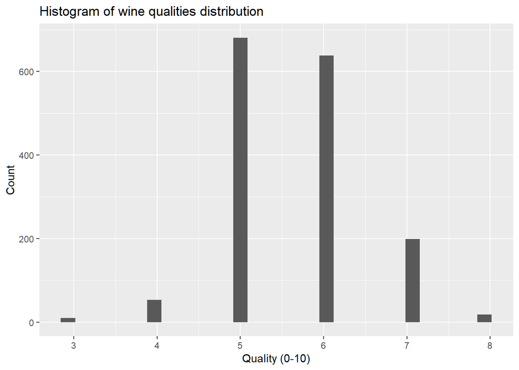

Most of the wine samples are centered on 5, 6, 7 the extreme low and extreme  
low can be considered as outliers or not enough samples

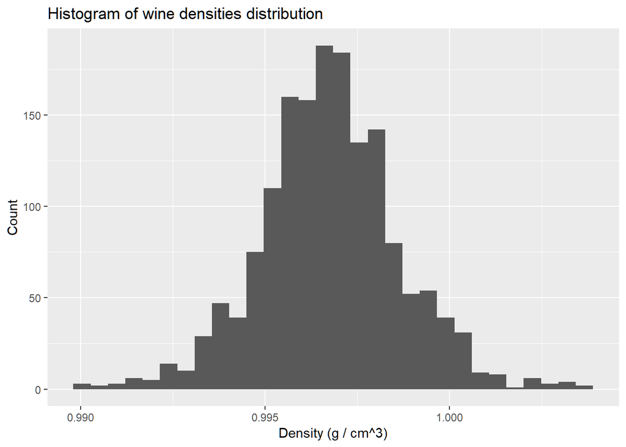

**Density of the wine is normally distributed**

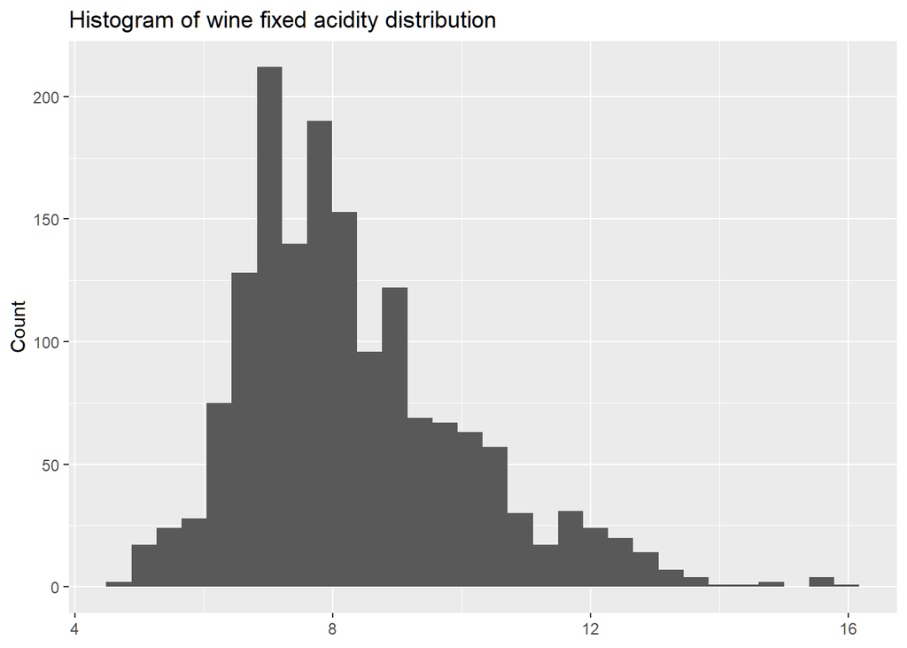

Most of the fixed acidity data is between 6 and 10 and the plot is right  
skewed

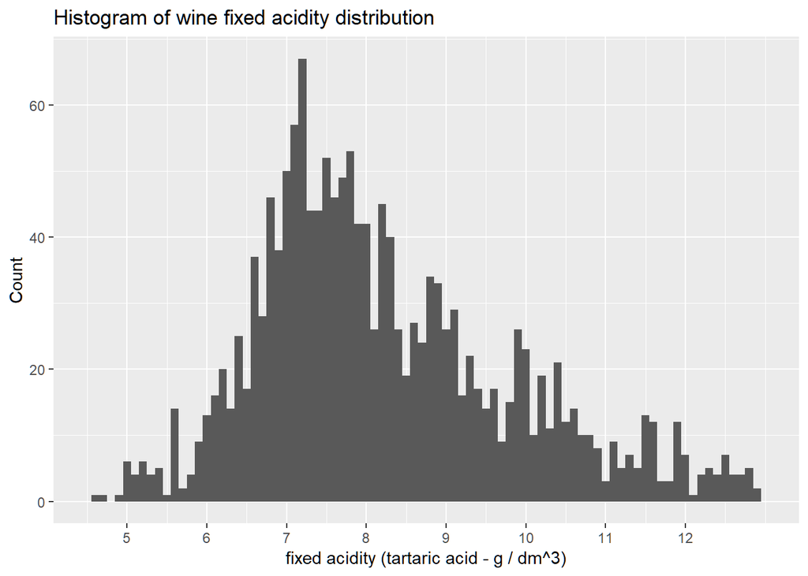

Most of the fixed acidity data is between 6 and 10 and the plot is right  
skewed the second plot shows the variation of the data points after using the binwidth and scale_x_continous, for the second plot after zooming in using  
limits assuming that the points from 13 to 17 are outliers, we can see fixed  
acidity is almost normally distributed

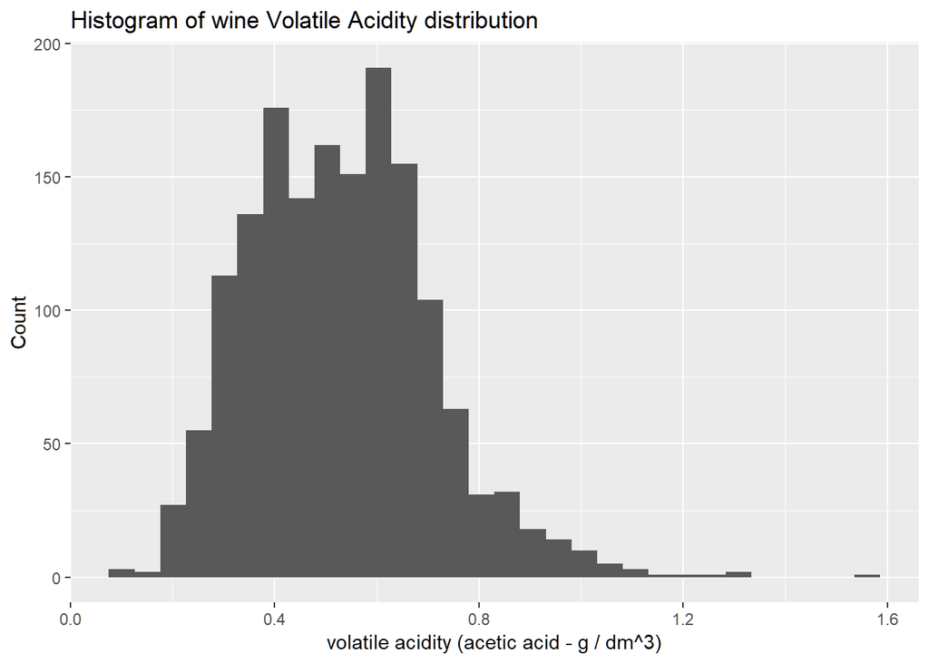

**Data points are between 0.2 and 0.8 and the plot is right skewed**

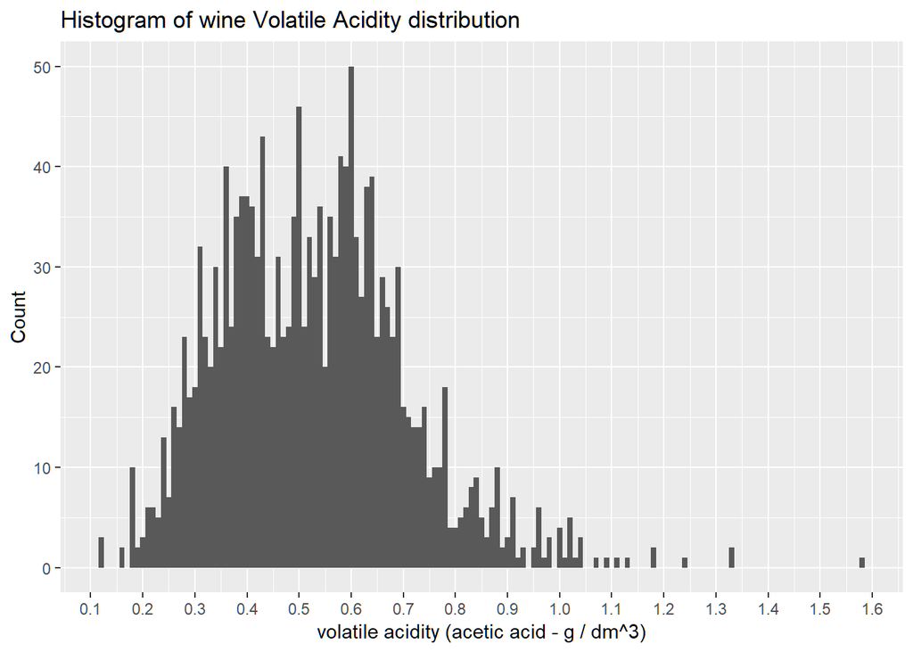

**Data points are between 0.2 and 0.8 and the plot is right skewed**

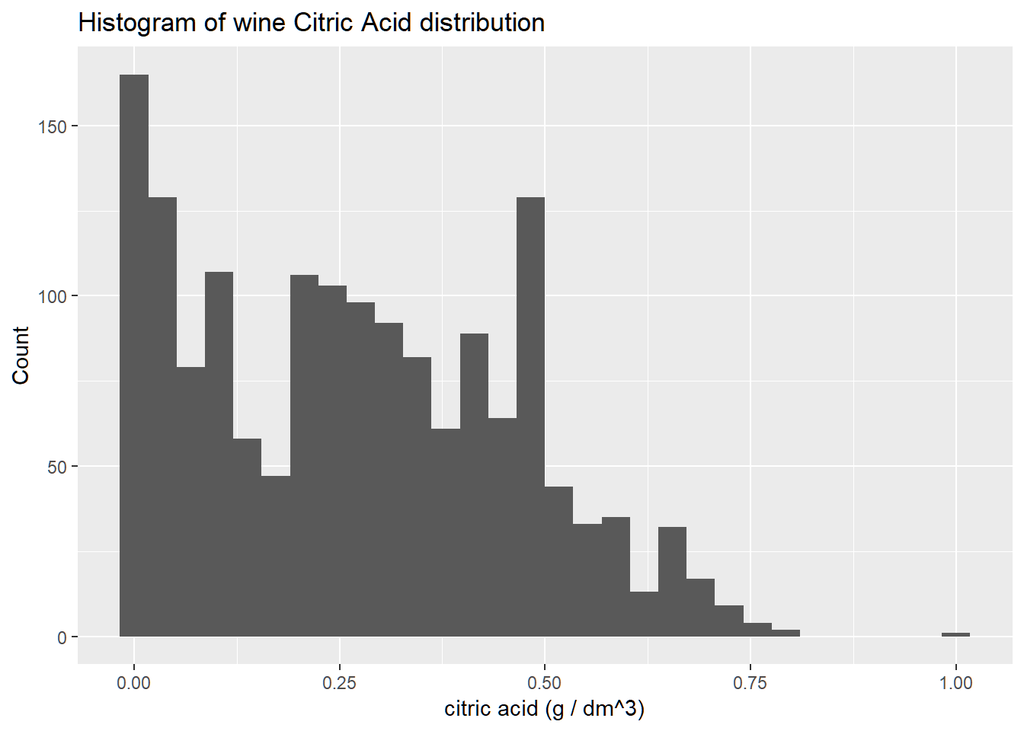

**Citric acid at 0.0 has the highest count next to it 0.50**

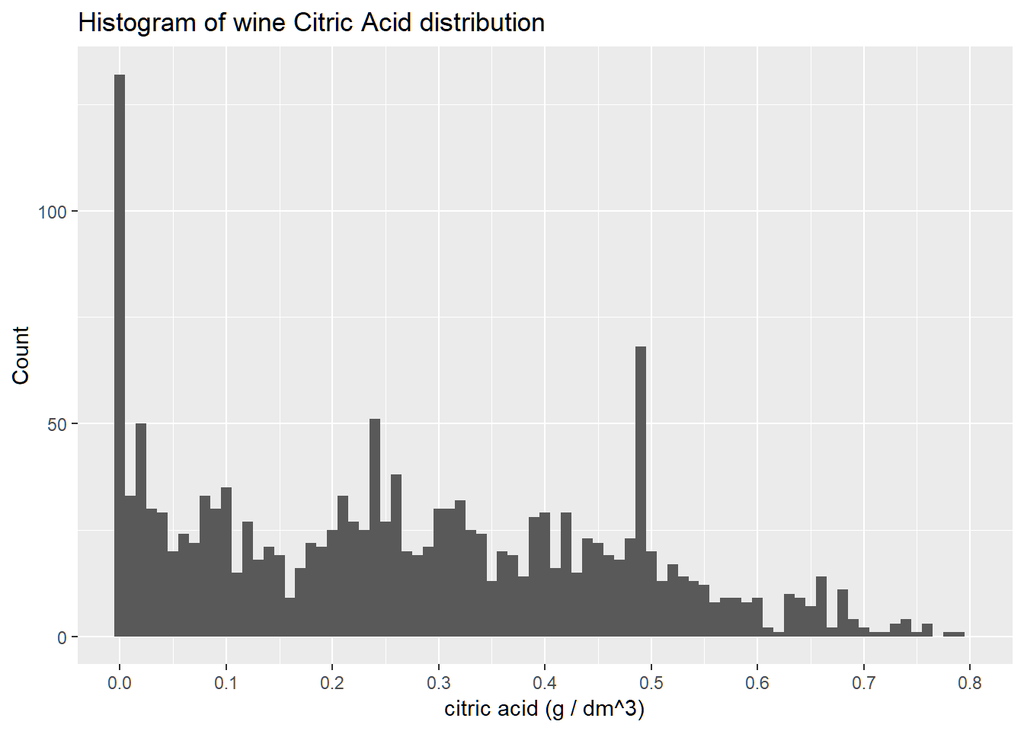

Citric acid at 0.0 has the highest count next to it 0.50, by setting the  
binwidth to 0.01 and zooming in to take out the outliers we have a clear view  
over the data distribution

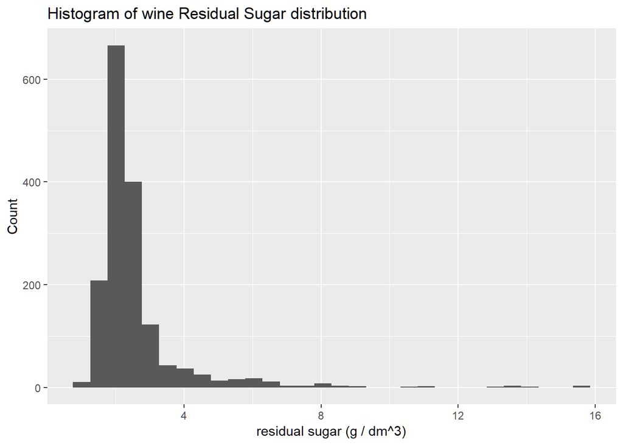

**Right skewed plot with most of the data points at 2**

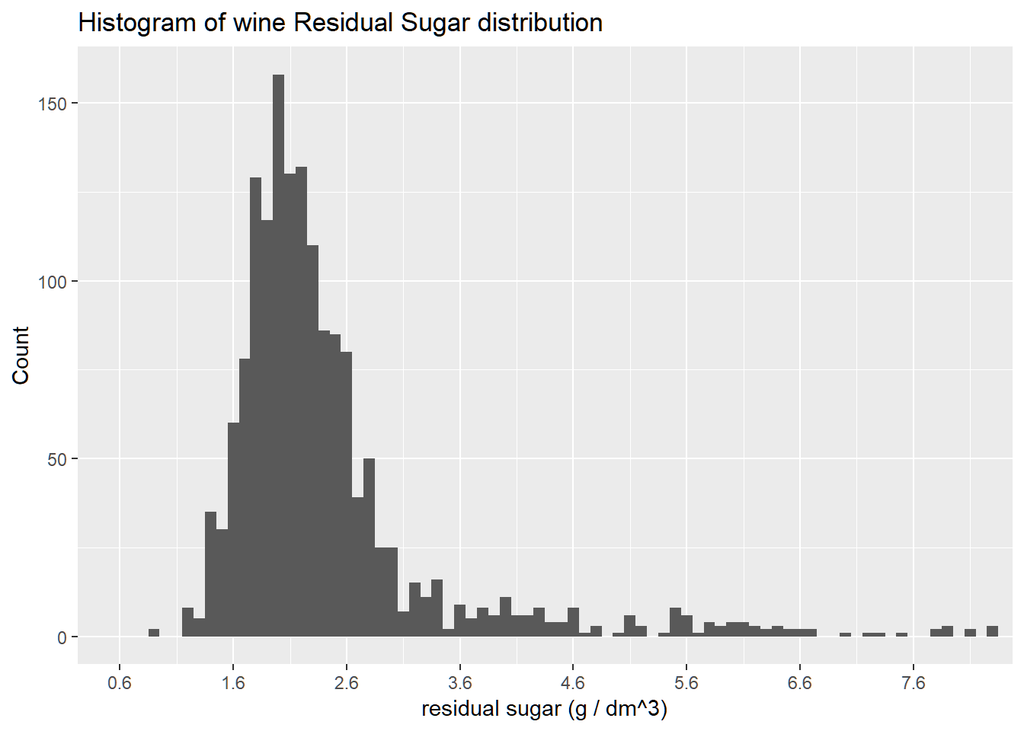

Right skewed plot with most of the data points at 2, I will note zoom in  
further as I will loose a lot of data points and we have a small number of  
observations

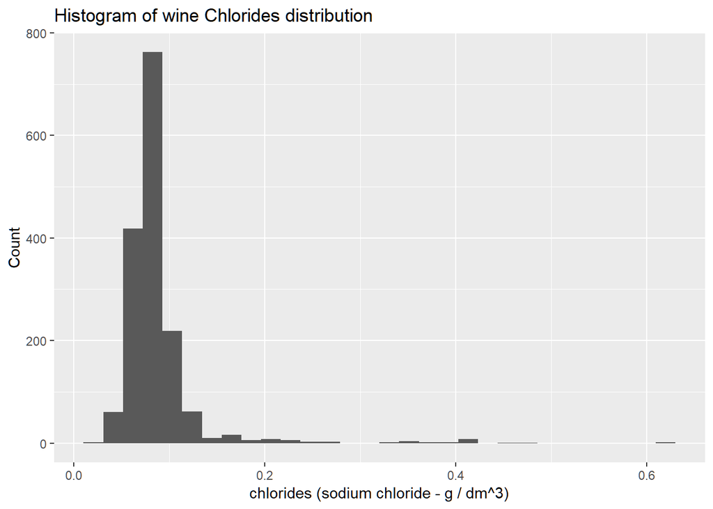

**Right skewed plot with most of the points around 0.1**

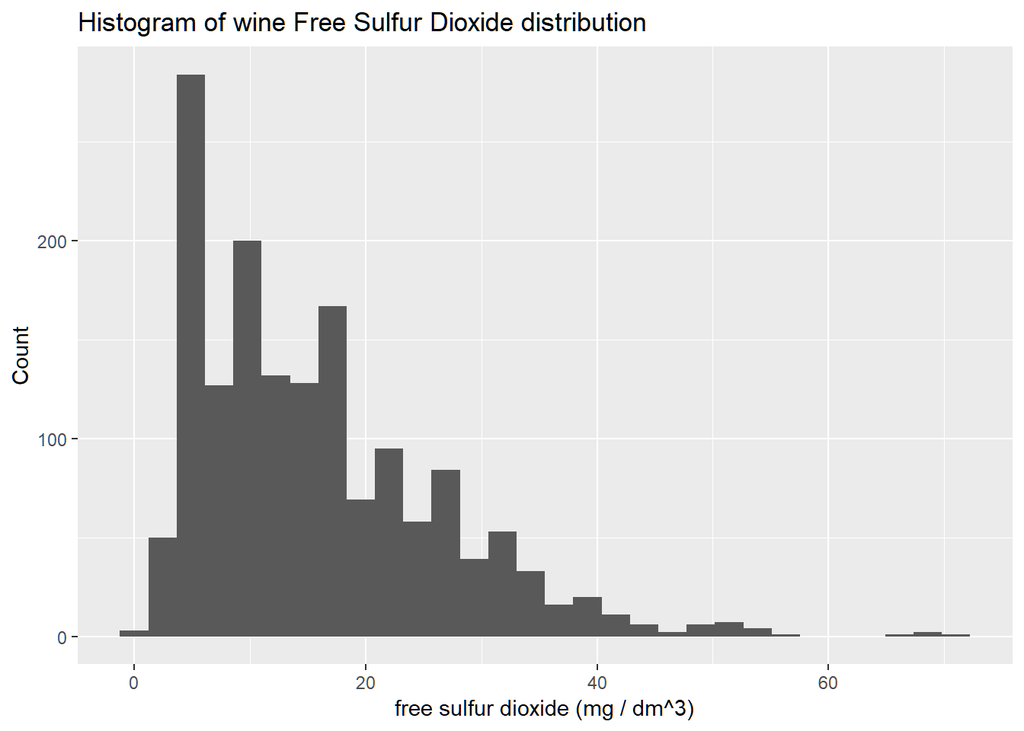

Right skewed plot with lower values having more count and probably any  
thing more than 40 could be an outliers

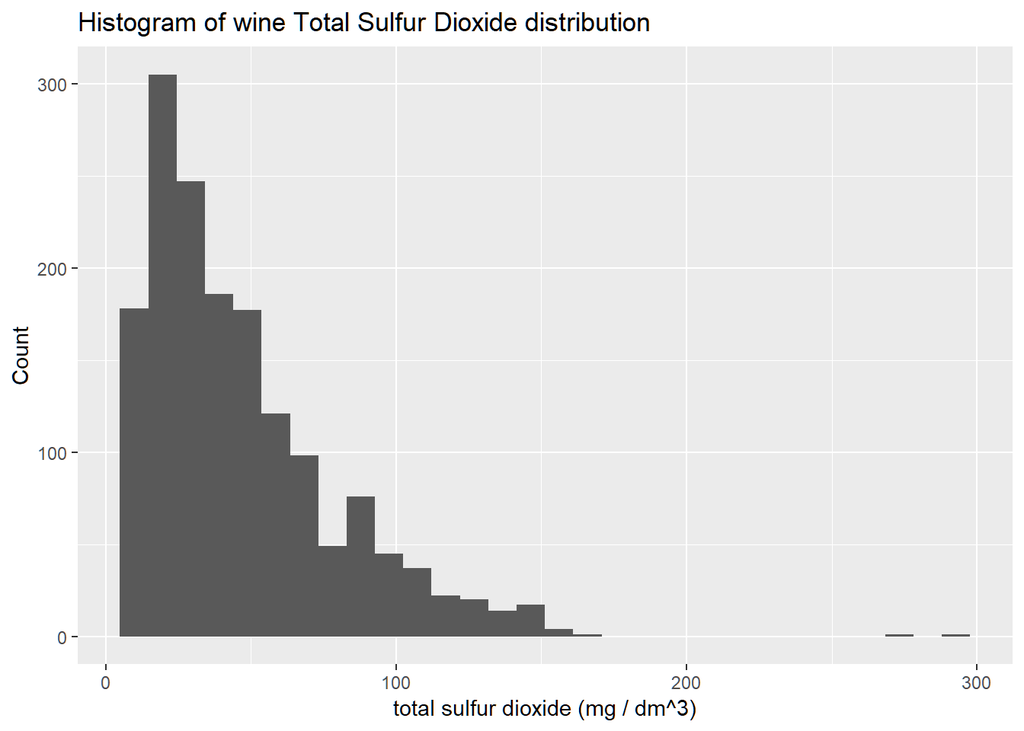

**Right skewed plot**

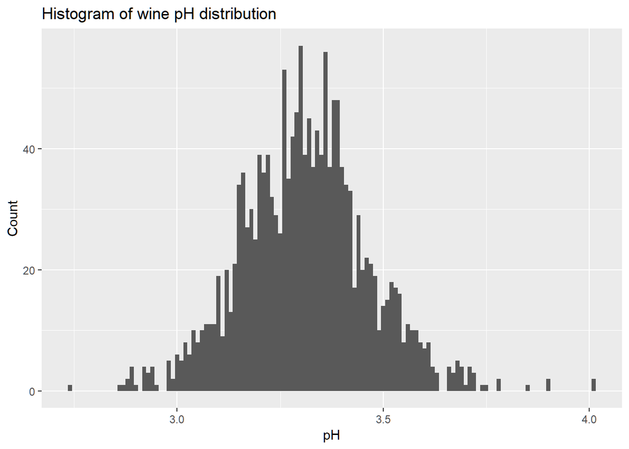

**pH is normally distributed**

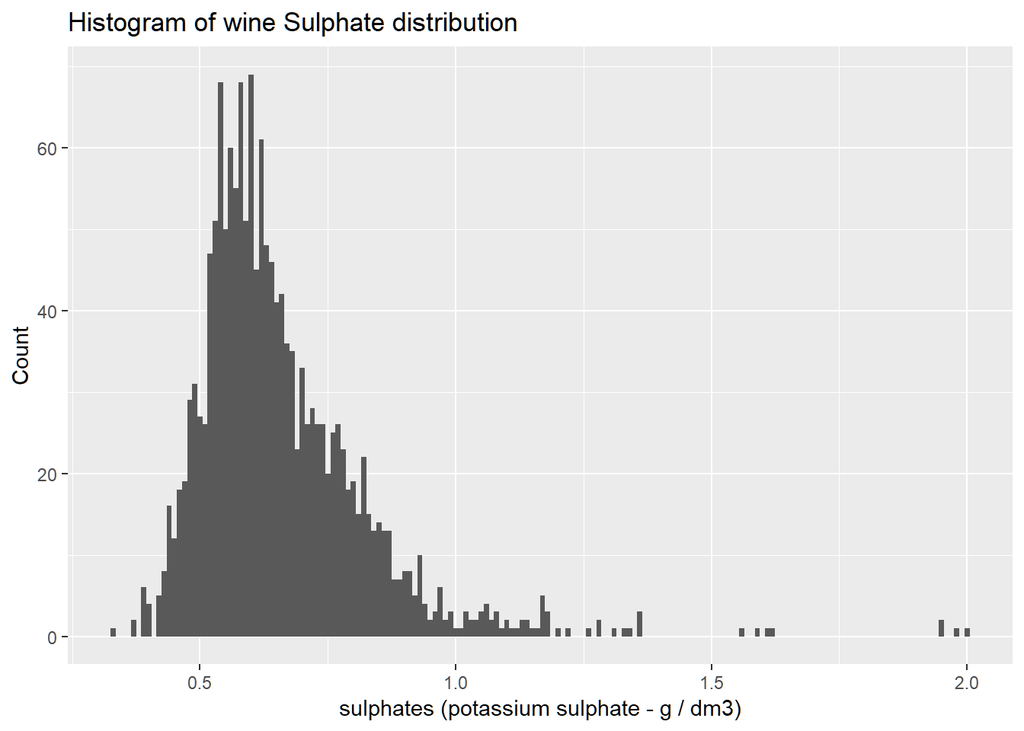

**Right skewed plot with values 0.3 to 1.0**

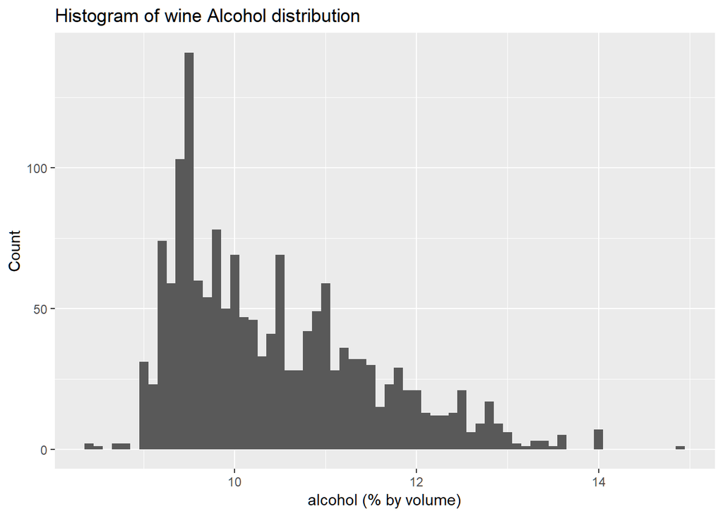

# Univariate Analysis

### What is the structure of your dataset?

- 12 variable (feature) with one outcome (quality).
- 1599 Observations.
- Quality is a categorical variable ordered from 0-10 where 0 is very bad and  
  10 very excellent and needs to be converted into ordered factor.
- There other 11 variables are numerics (float).

### What is/are the main feature(s) of interest in your dataset?

- Residual.sugar
- Alcohol
- Volatile.acidity
- Citric.acid
- Quality I will keep investigating to see a relevant other main feature in the dataset

### What other features in the dataset do you think will help support your investigation into your feature(s) of interest?

- pH
- total.sulfur.dioxide
- fixed.acidity
- density

### Did you create any new variables from existing variables in the dataset?

**No**

### Of the features you investigated, were there any unusual distributions? Did you perform any operations on the data to tidy, adjust, or change the form of the data? If so, why did you do this?

No, data is tidy from, and data quality is good, I just a changed data type  
of quality to become ordered factor and removed X variable as its not needed

# Bivariate Plots Section

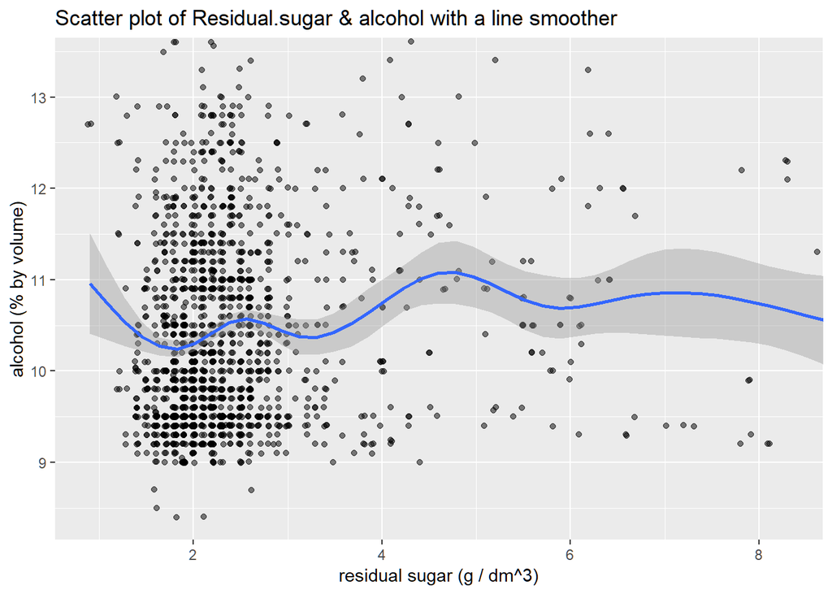

**There is no significant relation between the residual.sugra and alcohol**

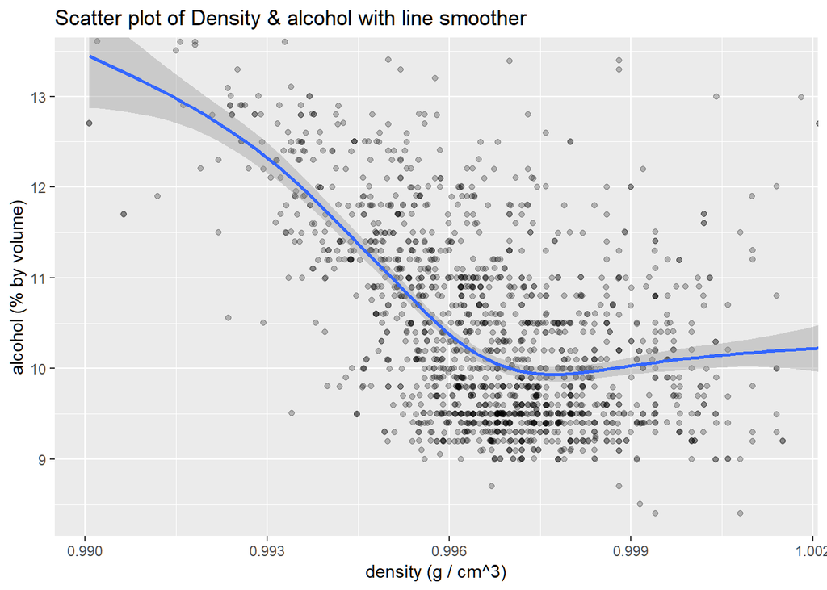

**There is a -ve kind of strong correlation between alcohol and density**

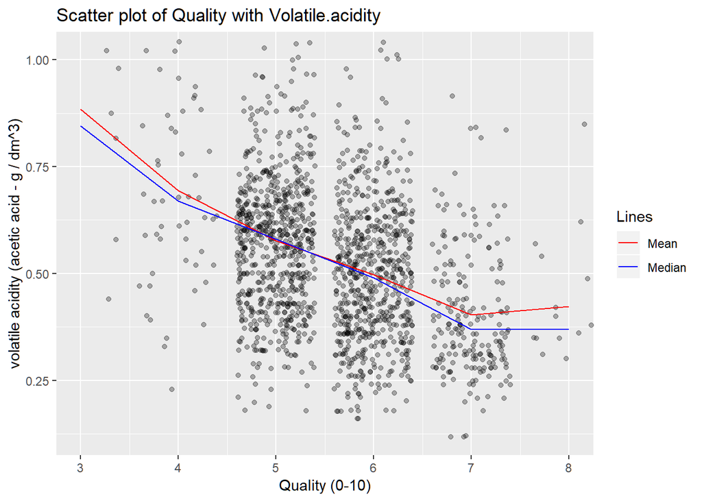

**It seems with decrease of the volatile.acidity the quality increases on average**

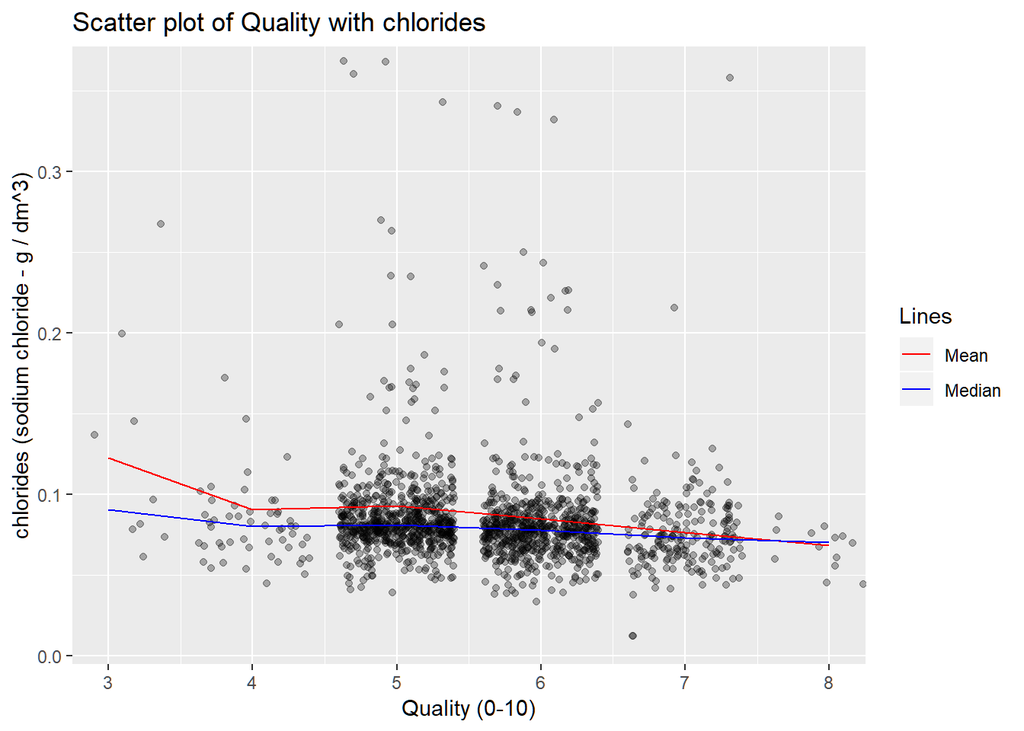

Quality at its best when the chlorides is between 0.05 and 0.1, also I can  
see that with the decrease of chlorides on average the quality goes up

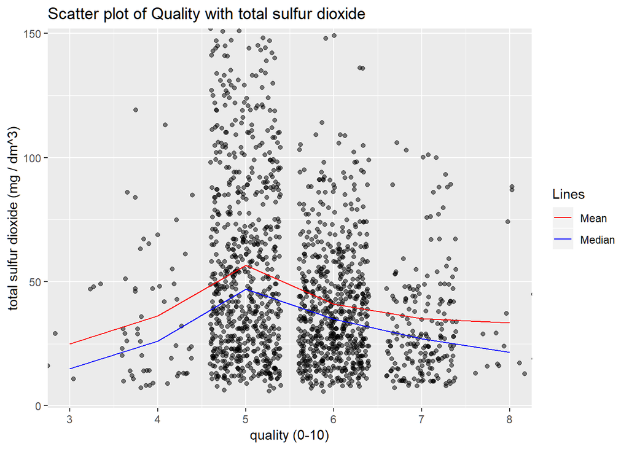

lower Total sulfur dioxide (TSD) is a contributor to better quality, however  
I see a lower TSD with a lower quality rating, this could be related to  
correlated variable another point to be considered is that there is not enough  
samples with quality level 3, 4, 8

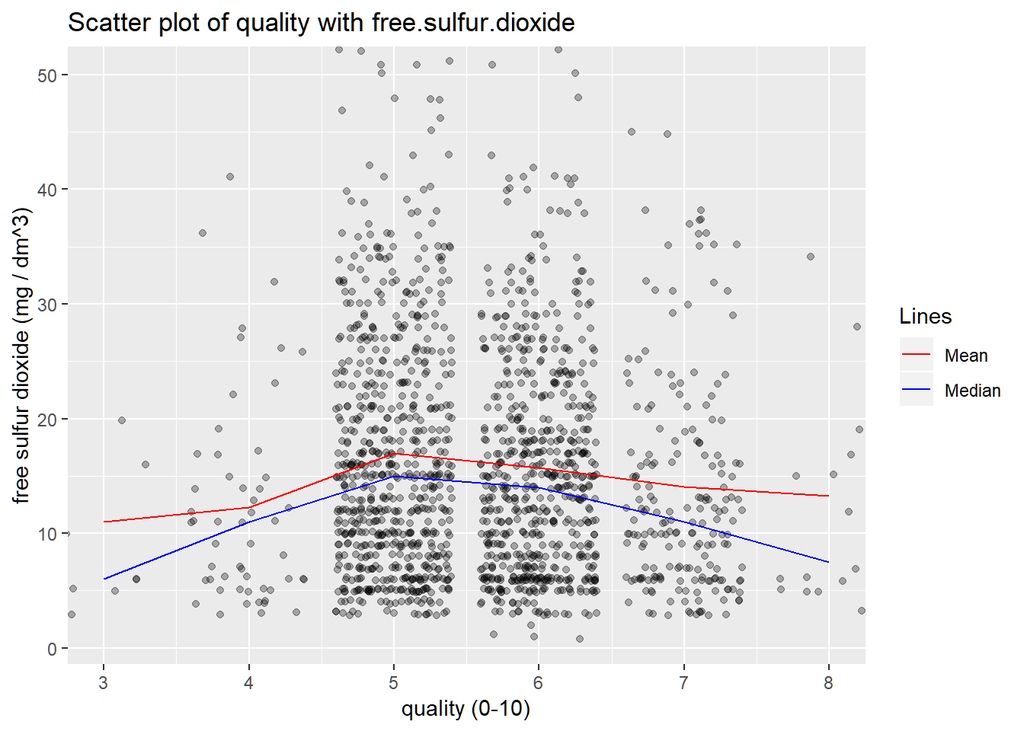

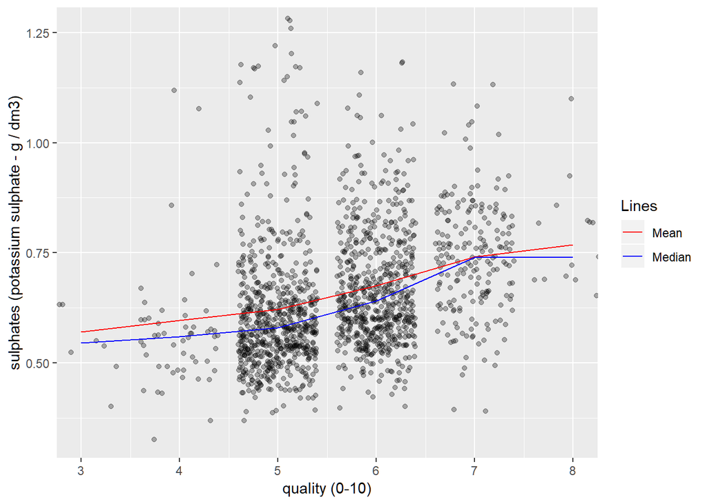

Sulphates & Quality: drawing the mean and median layers showed that the  
increase of sulphates contributes to better quality.

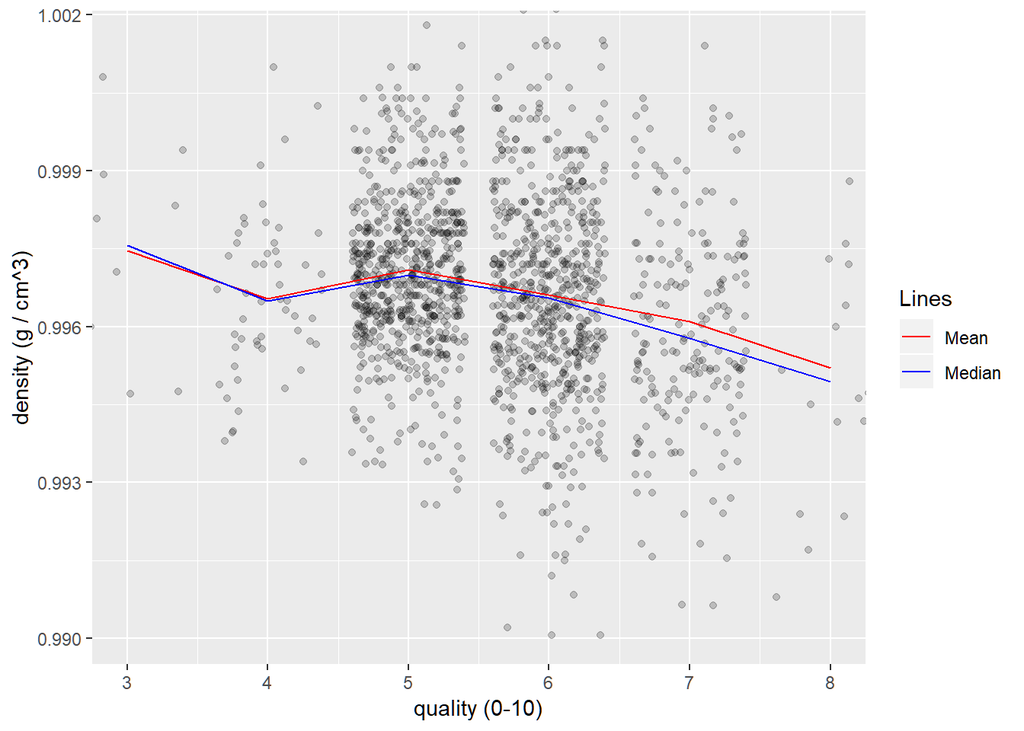

I can see that with the decrease of the density the quality improves, this is  
clear when we look at the median and mean lines

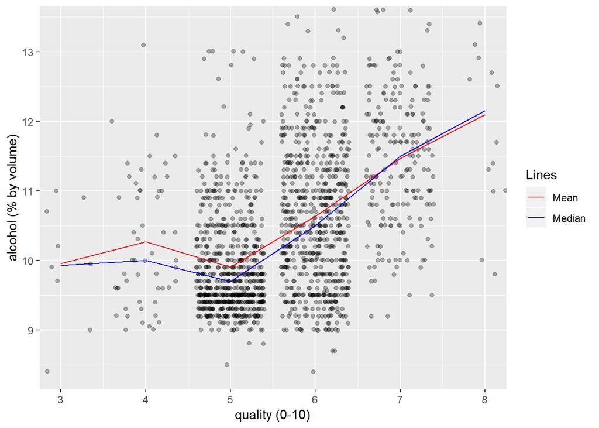

Alcohol does affect the quality as per the plot, as I see a trend with the  
increase of the alcohol

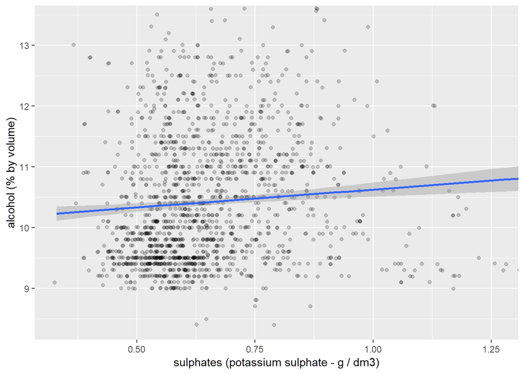

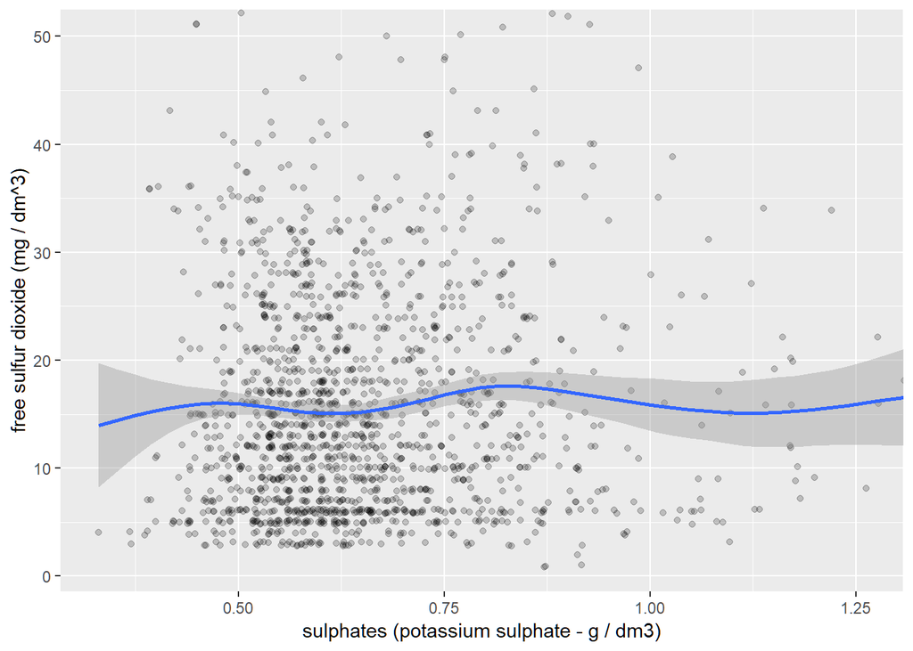

**there is no liner relation between sulphates and free.sulfur.dioxide**

# Bivariate Analysis

### Talk about some of the relationships you observed in this part of the investigation. How did the feature(s) of interest vary with other features in the dataset?

Alcohol $ residual.sugar: even by omitting the top 1% and zooming in,  
I still see no relation between the alcohol and residual.sugar.

Volatile.acidity & quality: I can see with the lower values of  
volatile.acidity the quality increases

**Alcohol & quality: the increase of alcohol indeed increases the quality**

Alcohol & density: I can see a -ve correlation between these 2 features,  
I will check these against quality to see how do they contribute to it.  
Quality & density: at a first look on the scatter I couldn’t find a relation  
but after adding 2 geom_line of median and mean , I can tell that on average  
lower density can mean a better quality.

### Did you observe any interesting relationships between the other features (not the main feature(s) of interest)?

Total.sulfur.dioxide & quality: generally a lower values of TSD can mean a  
better quality this relation needs to be investigated further with more  
variables

Free.sulfur.dioxide & sulphates: there is no direct relation seen in the  
graph

# Multivariate Plots Section

### Correlation

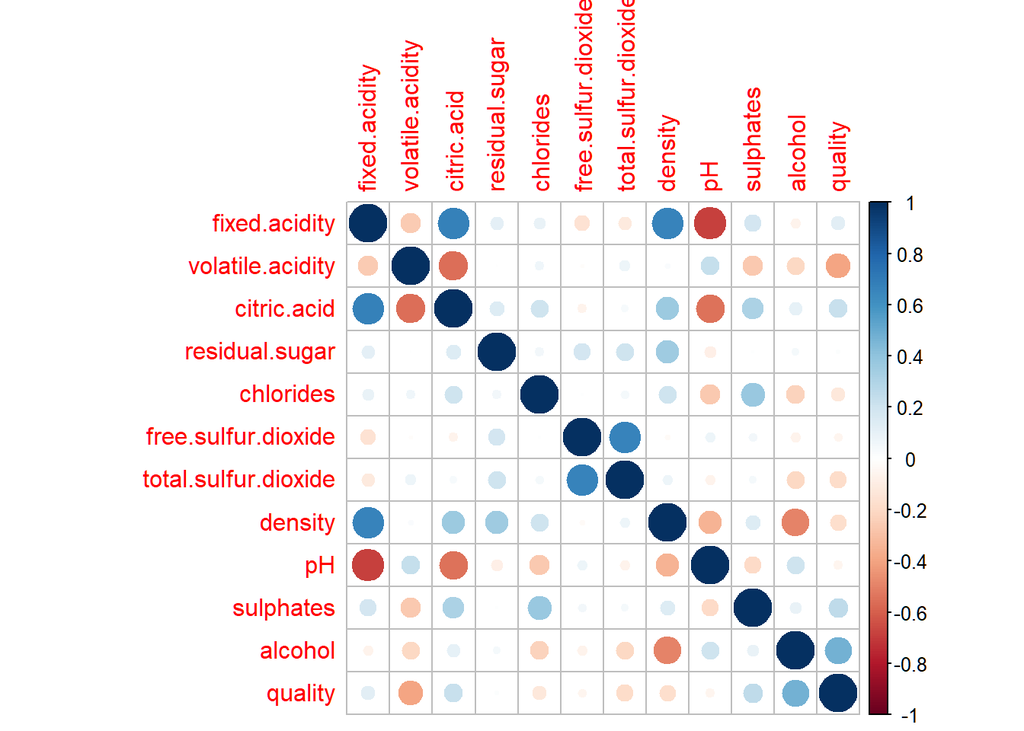

There is a significant correlation between the following:  
- citric acid & fixed acidity (Strong positive).  
- citric acid & volatile acidity (Moderate negative).  
- density & fixed acidity (Strong positive).  
- Total sulfur dioxide & free sulfur dioxide (Strong positive).  
- pH & fixed acidity (Strong negative).  
- pH & citric acid (Moderate Negative).  
- Density & Alcohol (Moderate Negative).  
- Quality & Alcohol (Moderate Positive).

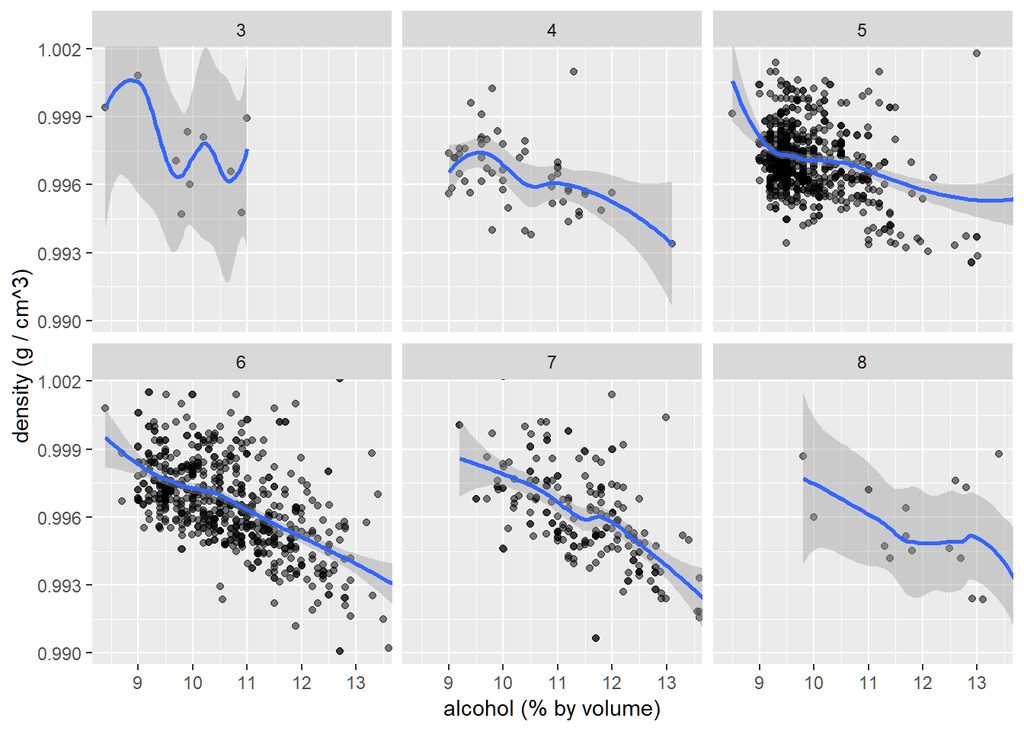

I can see a the relation between the density and alcohol with quality, lower  
density higher alcohol on average will result a better quality

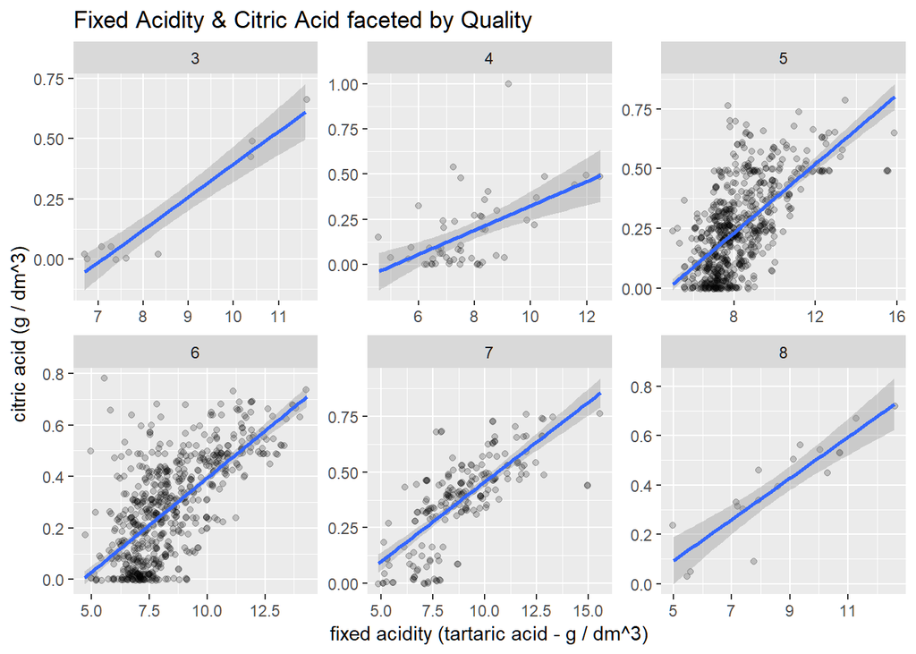

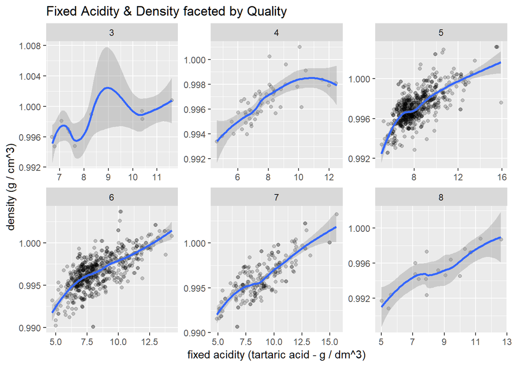

Even though there is a strong correlation between fixed acidity and density  
I see that there isn’t much of relation between these 2 features and the  
quality as on average these 2 features are the same on most of quality levels

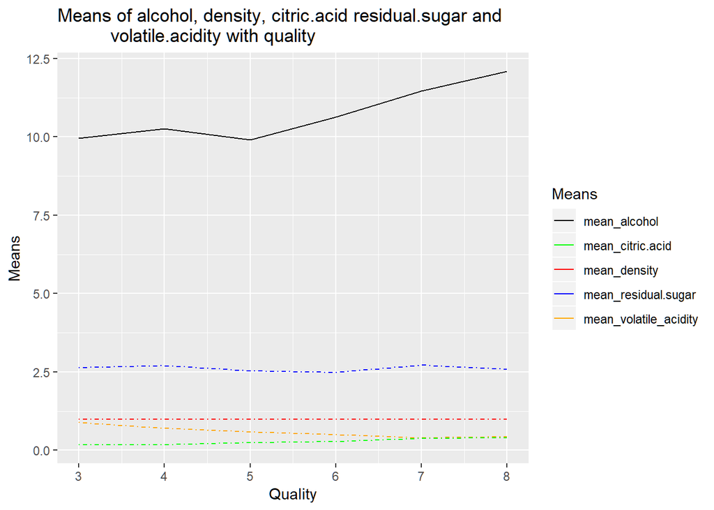